# BMS353 Bioinformatics for Biomedical Science - Week 6

Module Coordinator Mark Dunning

## Setup and Recap

```r
library(tidyverse)
library(DESeq2)
results_tgf  <- read_csv("out_data/DESeq_TGF_vs_CTR_annotated.csv")
dds <- readRDS("Robjects/dds.rds")
```

**Exercise**:

- Make another heatmap of the dataset, but this time using the 30 genes with the largest absolute fold-change
- The cells in the heatmap are often *scaled* at a gene-level according to the change from mean rather than absolute value. Look at the help for `pheatmap` to see how to change the heatmap
- It would be more informative to have the rows labeled according to the `SYMBOL` rather than Ensembl ID. Look at the help for `pheatmap`; which argument do you need to change? Look back at the code used to create the `de_ids` variables, and modify to obtain the `SYMBOL` corresponding to the 30 genes with the largest absolute fold-change.

```r
var_ids <- results_tgf %>%
  arrange(desc(abs(log2FoldChange))) %>%
  dplyr::slice(1:30) %>%
  pull("row")
var_ids
```

```
 [1] "ENSG00000207142" "ENSG00000279483" "ENSG00000275140"
 [4] "ENSG00000258588" "ENSG00000225415" "ENSG00000249141"
 [7] "ENSG00000259000" "ENSG00000167971" "ENSG00000206899"
[10] "ENSG00000164684" "ENSG00000213514" "ENSG00000146938"
[13] "ENSG00000263620" "ENSG00000145451" "ENSG00000124208"
[16] "ENSG00000263887" "ENSG00000260272" "ENSG00000213355"
[19] "ENSG00000267645" "ENSG00000202198" "ENSG00000256349"
[22] "ENSG00000277971" "ENSG00000261641" "ENSG00000274044"
[25] "ENSG00000269242" "ENSG00000260389" "ENSG00000226065"
[28] "ENSG00000237463" "ENSG00000267122" "ENSG00000224677"
```

```r
library(pheatmap)
vsd <- vst(dds)
```

```
using 'avgTxLength' from assays(dds), correcting for library size
```

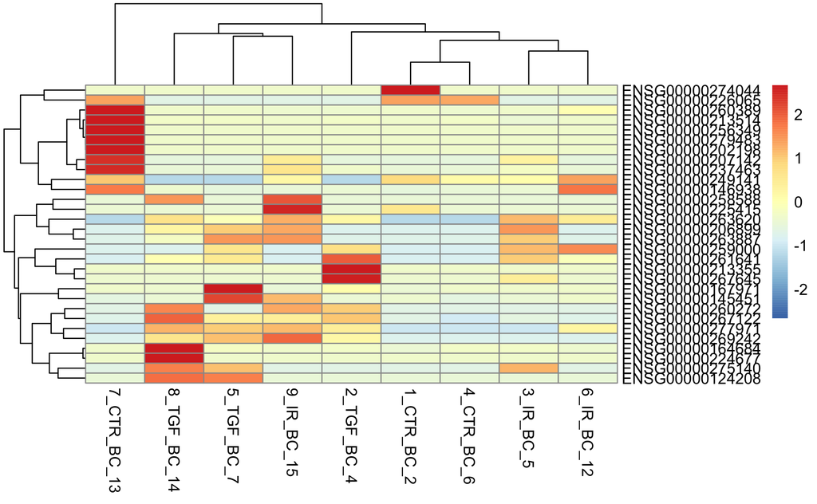

```r
heatmap_data <- assay(vsd)[var_ids,]
pheatmap(heatmap_data,scale="row")
```

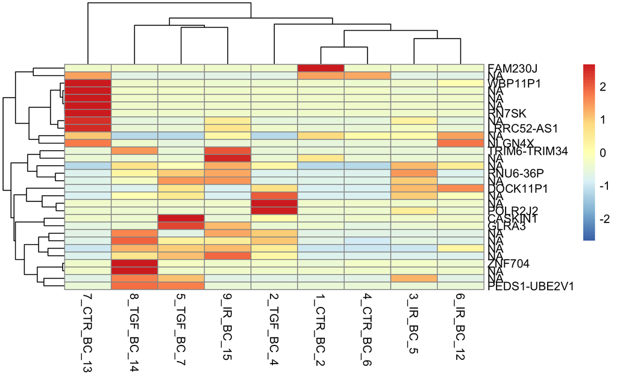

```r
new_labs <- results_tgf %>%
  arrange(desc(abs(log2FoldChange))) %>%
  dplyr::slice(1:30) %>%
  pull("SYMBOL")

pheatmap(heatmap_data,scale="row",labels_row = new_labs)
```

**Exercise**: Make a plot to demonstrate whether the genes belonging to the ECM pathway are more significant (as measured by -log$_{10}$ adjusted p-value) than genes that do not belong to the pathway.

```r
library(org.Hs.eg.db)
pathway_genes <- AnnotationDbi::select(org.Hs.eg.db,
                                       keys = "GO:0030198",
                                       keytype = "GO",
                                       columns="ENSEMBL") %>% pull(ENSEMBL)
```

[output not shown]

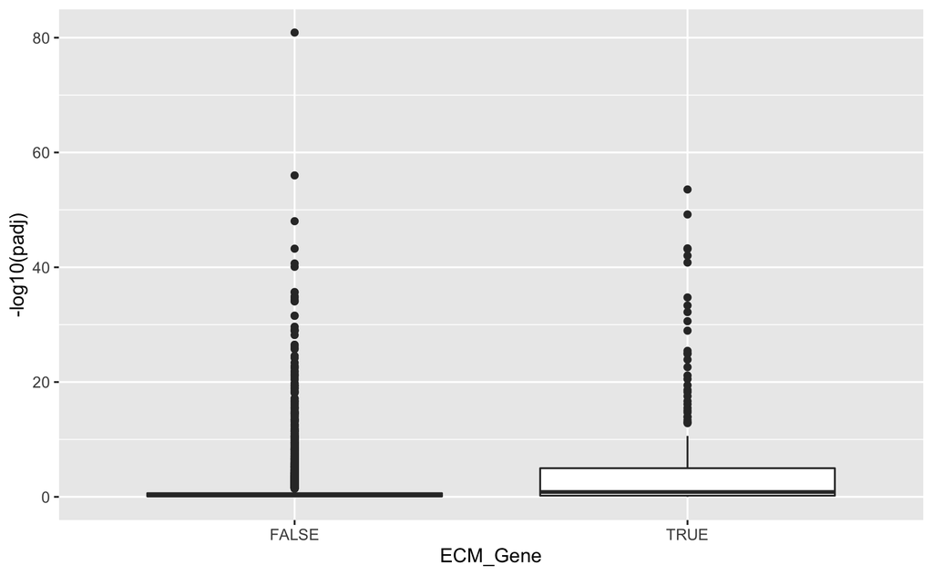

```r
results_tgf %>%
  mutate(ECM_Gene = row %in% pathway_genes,"") %>%
  ggplot(aes(x = ECM_Gene, y = -log10(padj))) + geom_boxplot()
```

## Exercise

- In addition to enriched GO terms, `clusterProfiler` can also find enriched [KEGG](https://www.genome.jp/kegg/) terms using the `enrichKEGG` function. There are a couple of changes that are required from `enrichGO`
  - `ENTREZID` have to be used as the identifer type
  - the user must input an appropriate [organism code](https://www.genome.jp/kegg/catalog/org_list.html). The code for humans is `hsa`.
- Use the `enrichKEGG` function to identify enriched KEGG terms in the analysis.
- (Optional) If you have time, use the gseKEGG to perform GSEA using KEGG terms.

```r
?enrichKEGG

library(clusterProfiler)
universe <- results_tgf %>% pull(ENTREZID)
sigGenes <- results_tgf %>%
  filter(padj < 0.05, !is.na(row)) %>% pull(ENTREZID)

enrich_kegg <- enrichKEGG(
  gene= sigGenes,
  organism = "hsa",
  qvalueCutoff = 0.05
)
enrich_kegg %>% data.frame
```

|  | ID | Description | GeneRatio | BgRatio | pvalue | p.adjust | qvalue | geneID | Count |
| --- | --- | --- | --- | --- | --- | --- | --- | --- | --- |
| hsa04512 | hsa04512 | ECM-receptor interaction | 34/1001 | 88/8135 | 2.460806e-10 | 8.071444e-08 | 7.019773e-08 | 1282/2335/7058/948/1284/1288/22801/3910/1311/1277/1293/3912/3909/3696/3693/961/6382/1287/3673/3655/3339/8516/960/1278/3672/5649/7057/1286/3915/6385/3694/341640/375790/3690 | 34 |
| hsa04151 | hsa04151 | PI3K-Akt signaling pathway | 79/1001 | 354/8135 | 5.144971e-08 | 8.437753e-06 | 7.338354e-06 | 1282/2335/7058/2252/1284/1288/2069/80310/1129/54541/22801/23…… | 79 |
| hsa04974 | hsa04974 | Protein digestion and absorption | 31/1001 | 103/8135 | 1.145388e-06 | 1.108726e-04 | 9.642640e-05 | 1282/1301/2006/1296/1284/1803/1289/1288/7373/1277/6520/1293/1307/255631/9056/50509/5547/1294/1287/483/1290/136227/1278/4311/54407/1281/476/85301/1303/1286/23428 | 31 |
| hsa04510 | hsa04510 | Focal adhesion | 49/1001 | 201/8135 | 1.352105e-06 | 1.108726e-04 | 9.642640e-05 | 1282/2335/7058/1284/1288/80310/22801/3082/3910/1311/1277/129…… | 49 |
| hsa05205 | hsa05205 | Proteoglycans in cancer | 48/1001 | 205/8135 | 5.791999e-06 | 3.799551e-04 | 3.304488e-04 | 2335/4313/7482/3082/27250/8325/1277/7078/117581/7099/4660/74…… | 48 |
| hsa04933 | hsa04933 | AGE-RAGE signaling pathway in diabetic complications | 28/1001 | 100/8135 | 1.720516e-05 | 9.405487e-04 | 8.179997e-04 | 1282/2335/4313/1284/1288/2152/7412/1277/3569/4088/185/1287/50507/5335/3553/3552/113026/3383/1278/1019/7422/1281/208/51196/7423/1286/581/5293 | 28 |
| hsa05165 | hsa05165 | Human papillomavirus infection | 64/1001 | 331/8135 | 1.230182e-04 | 5.056623e-03 | 4.397769e-03 | 1282/2335/7058/5743/1284/1288/7482/22801/3910/1311/8325/5525…… | 64 |
| hsa05418 | hsa05418 | Fluid shear stress and atherosclerosis | 33/1001 | 139/8135 | 1.233323e-04 | 5.056623e-03 | 4.397769e-03 | 4313/3554/4257/7412/652/5154/2947/10365/6382/1728/8878/7295/3553/4258/3552/3383/5563/4217/7422/2941/9446/208/4205/1843/2946/6385/5609/2817/3690/4208/2949/5293/5175 | 33 |
| hsa05222 | hsa05222 | Small cell lung cancer | 23/1001 | 92/8135 | 5.859323e-04 | 1.983119e-02 | 1.724728e-02 | 1282/2335/5743/1284/1288/3910/5915/3912/3909/1287/3673/3655/1019/1030/9618/208/4792/578/1286/3915/4616/581/5293 | 23 |
| hsa04390 | hsa04390 | Hippo signaling pathway | 34/1001 | 157/8135 | 6.188569e-04 | 1.983119e-02 | 1.724728e-02 | 7482/374/8325/650/7472/122786/2535/652/1490/10971/4088/26524/64398/8313/60485/23291/8200/27113/5519/1857/8312/84962/2736/5520/151449/8945/268/4092/1856/4771/3397/6932/10207/7005 | 34 |

[output cut: 18 more lines]